Skip to contents

# 🐟 物种与国家分析

Source: [`vignettes/articles/zh/species-countries.Rmd`](https://github.com/Linbojun99/faofishingreport/blob/main/vignettes/articles/zh/species-countries.Rmd)

```r
fao_settings(lang = "zh")   # 本文所有图表使用中文
```

📦 **数据来源**：[FAO全球捕捞产量](https://www.fao.org/fishery/collection/capture/en)（Global Capture Production）**2026.1.0**版（FAO于2026-03-30发布，1950–2024年），下载地址Capture_2026.1.0.zip，许可证[CC BY 4.0](https://creativecommons.org/licenses/by/4.0/)。用`fao_data_info()`查看你使用的版本和引用格式。

这些函数以`fishing_area_data()`返回的渔区数据（这里是27渔区）为输入，聚焦于单个物种或单个国家。`country_analysis()`则分析一个国家在全部FAO渔区的捕捞情况。

```r
FAO27 <- fishing_area_data("Atlantic, Northeast")
```

## 1️⃣ `species_country()`：某个物种由哪些国家捕捞

物种名必须与FAO物种名称完全一致；不妨先看看该渔区的主要物种：

```r
top <- aggregate(Production ~ ASFIS.species..Name., data = FAO27$area_data, FUN = sum)
head(top[order(-top$Production), "ASFIS.species..Name."], 10)
```

```
#>  [1] "Atlantic herring"          "Atlantic cod"
#>  [3] "Capelin"                   "Blue whiting(=Poutassou)"
#>  [5] "Atlantic mackerel"         "Sandeels(=Sandlances) nei"
#>  [7] "European sprat"            "Saithe(=Pollock)"
#>  [9] "Haddock"                   "Norway pout"
```

```r
cod <- species_country(FAO27$area_data, species_name = "Atlantic cod")
```

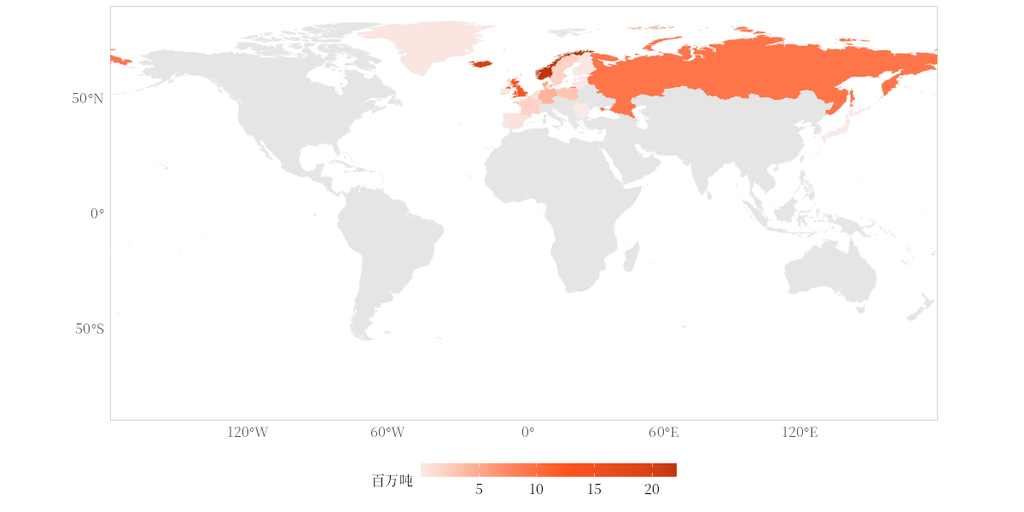

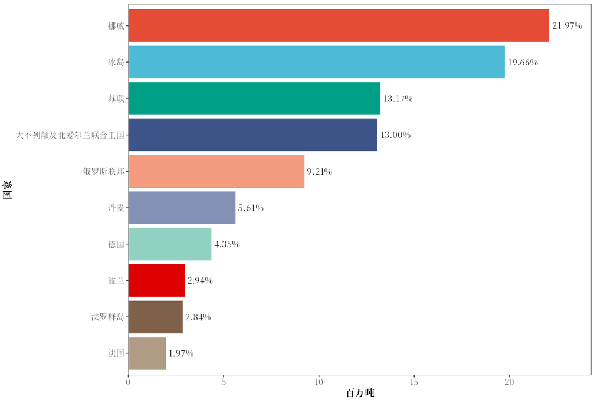

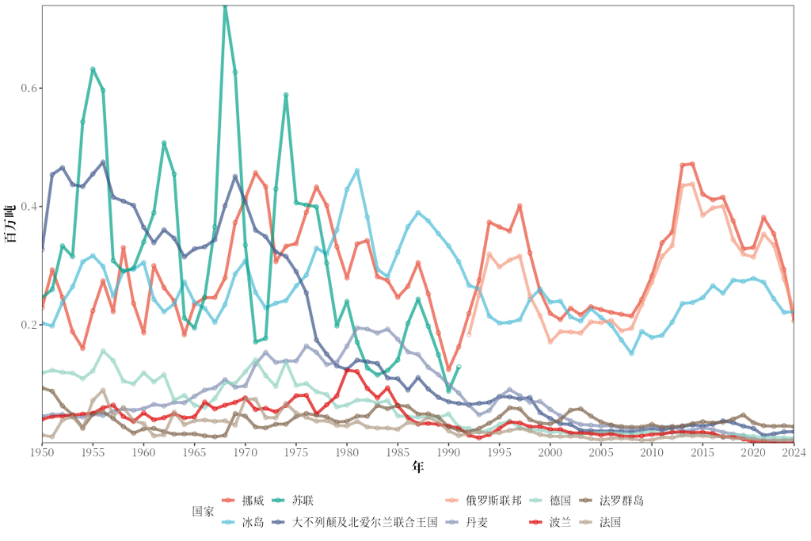

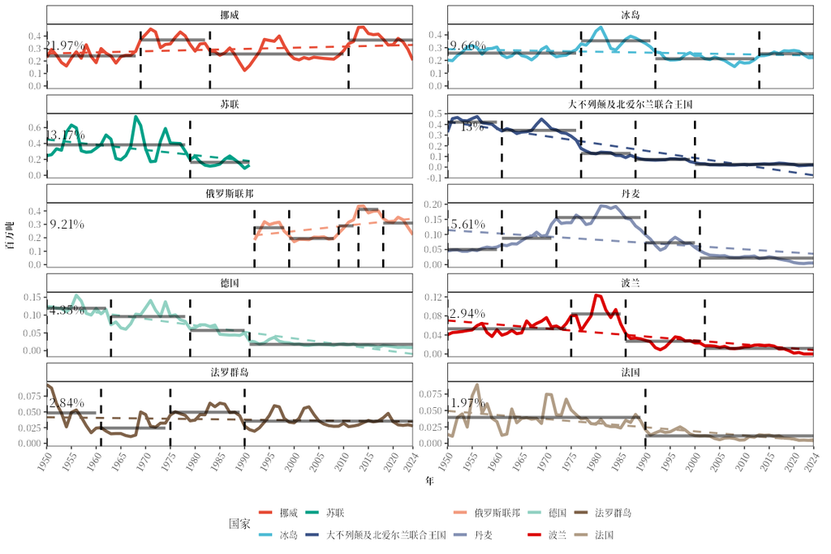

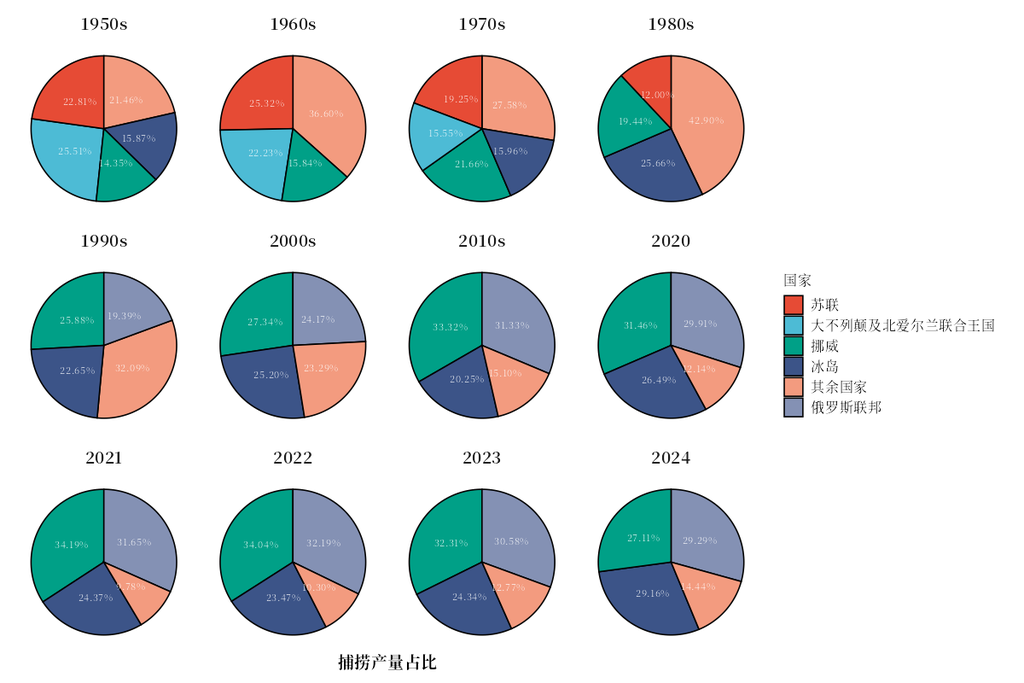

文件名中的`<species>`是把物种名中的空格和标点替换为`_`后的名称（如`Atlantic_cod`）：

| 文件 | 图表 |
| --- | --- |
| `<species>_country_map.png` | 世界地图：各国历年累计的该物种产量 |
| `species/<species>_country_ranked_total.png` | 所选国家（默认为前十名）的总产量及占比 |
| `species/<species>_country_ranked.png` | 这些国家的产量随时间的变化 |
| `species/<species>_country_ranked_wrap.png` | 每个国家一个分面，标出占比、线性趋势和平均产量的突变点（设置`timeseries_analysis = FALSE`时为平滑曲线） |
| `species/<species>_country_pie_selected.png` | 主要国家在各年代以及当前年代逐年的占比（最多四个国家，其余合并） |

表格`tables/<species>_country_ranked_table.csv`列出每个国家各年代的平均产量、最近五年的产量，以及最后一年的占比：

```r
table <- read.csv("tables/Atlantic_cod_country_ranked_table.csv",
                  fileEncoding = "UTF-8-BOM", check.names = FALSE)
show_table(table, n = 10, digits = 0)
```

| Country..Name. | 1950s | 1960s | 1970s | 1980s | 1990s | 2000s | 2010s | 2020s | 2020 | 2021 | 2022 | 2023 | 2024 | total_2024_production | percentage_of_total_2024 |
| --- | --- | --- | --- | --- | --- | --- | --- | --- | --- | --- | --- | --- | --- | --- | --- |
| 丹麦 | 49,390 | 78,840 | 138,487 | 165,392 | 73,986 | 33,334 | 22,034 | 5,230 | 6,996 | 4,448 | 3,654 | 5,440 | 5,610 | 5,610 | 1 |
| 俄罗斯联邦 | NA | NA | NA | NA | 214,118 | 196,751 | 364,080 | 300,680 | 314,422 | 353,303 | 334,655 | 277,721 | 223,297 | 223,297 | 29 |
| 冰岛 | 265,890 | 246,870 | 282,864 | 365,598 | 250,113 | 205,186 | 235,340 | 247,559 | 278,442 | 272,045 | 243,991 | 221,009 | 222,309 | 222,309 | 29 |
| 大不列颠及北爱尔兰联合王国 | 427,430 | 358,120 | 275,555 | 112,584 | 69,885 | 25,002 | 29,324 | 18,373 | 24,762 | 13,001 | 15,645 | 19,051 | 19,404 | 19,404 | 3 |
| 德国 | 121,200 | 89,570 | 103,867 | 57,171 | 28,332 | 17,077 | 15,114 | 9,676 | 11,507 | 9,187 | 9,900 | 9,085 | 8,699 | 8,699 | 1 |
| 挪威 | 240,370 | 255,160 | 383,889 | 277,006 | 285,810 | 222,616 | 387,177 | 313,285 | 330,767 | 381,594 | 353,966 | 293,408 | 206,691 | 206,691 | 27 |
| 法国 | 43,990 | 32,530 | 50,235 | 31,332 | 18,433 | 8,751 | 10,046 | 5,288 | 6,659 | 4,710 | 4,995 | 4,601 | 5,474 | 5,474 | 1 |
| 法罗群岛 | 50,750 | 20,140 | 38,589 | 51,879 | 36,275 | 38,108 | 34,271 | 29,977 | 34,510 | 29,453 | 28,542 | 29,504 | 27,875 | 27,875 | 4 |
| 波兰 | 48,440 | 53,090 | 66,401 | 71,149 | 24,222 | 16,289 | 14,938 | 1,069 | 1,800 | 3,164 | 129 | 148 | 104 | 104 | 0 |
| 苏联 | 382,090 | 407,780 | 341,246 | 170,941 | 21,676 | NA | NA | NA | NA | NA | NA | NA | NA | NA | NA |

设置`timeseries_analysis = TRUE`时，函数返回一个包含两个数据框的列表：所选国家逐年的产量（`cod[[1]]`）和它们的突变点（`cod[[2]]`：每个时段的起始年、结束年和平均产量）；设置`timeseries_analysis = FALSE`时只返回前者。

### 参数

| 参数 | 含义 | 默认值 |
| --- | --- | --- |
| `area_data` | 渔区产量数据：`fishing_area_data()$area_data`或`load_fao_data()`的任意子集 |  |
| `species_name` | FAO物种名（ASFIS英文名，与数据中一致） |  |
| `rank_range` | 显示的国家名次（按该物种历年总产量排序）：`1:10`为前十名，`c(5, 6)`为第五和第六名 | `1:10` |
| `plot` | 保存图表 | `TRUE` |
| `table` | 在`tables/`中保存表格 | `TRUE` |
| `timeseries_analysis` | `TRUE`：分面图显示线性趋势和突变点；`FALSE`：分面图显示平滑（loess）曲线 | `TRUE` |
| `h_value` | 相邻突变点之间时段的最短长度：占序列的比例或年数 | `0.15` |
| `polygon_color` | 地图上国界线的颜色 | `"grey90"` |
| `fill_scale` | 地图色板，可用`fao_settings()`中`map_palette`的任一取值 | `NULL`：`fao_settings()`中的`map_palette`（`"deep-orange"`） |
| `axis_title_face` | 地图坐标轴标题的字形 | `"bold"` |
| `axis_title_size_map` | 地图坐标轴标题的字号 | `14` |
| `axis_text_size_map` | 地图坐标轴标签的字号 | `12` |
| `legend_text_size_map` | 地图图例文字的字号 | `12` |
| `axis_text_size`、`axis_title_size` | 其他图表坐标轴标签和标题的字号 | `10`、`12` |
| `strip_text_size`、`strip_text_face` | 分面标题的字号和字形 | `12`、`"bold"` |
| `ZH` | 指定中文的旧方式：`TRUE`等同于`lang = "zh"` | `FALSE` |
| `lang` | 图表文字和名称的语言：`"en"`、`"zh"`或`"both"` | `NULL`：`ZH = TRUE`时为`"zh"`，否则使用`fao_settings()`中的语言 |
| `pptx` | 同时保存可编辑的PowerPoint文件 | `FALSE`，或`fao_settings()`中的`pptx` |
| `plot_show` | 保存图表的同时把图画在绘图窗口中（例如RStudio的Plots窗格） | `FALSE`，或`fao_settings()`中的`plot_show` |

在当前版本中，`species_country()`的排名图、时间序列图、分面图和饼图使用固定的字号：`axis_text_size`、`axis_title_size`、`strip_text_size`和`strip_text_face`可以传入，但不会改变这些图。地图的参数有效。

有些国家的金枪鱼产量序列较短；把`h_value`设大一些，突变点会更清晰：

```r
species_country(FAO27$area_data, species_name = "Atlantic bluefin tuna", h_value = 5, lang = "zh")
```

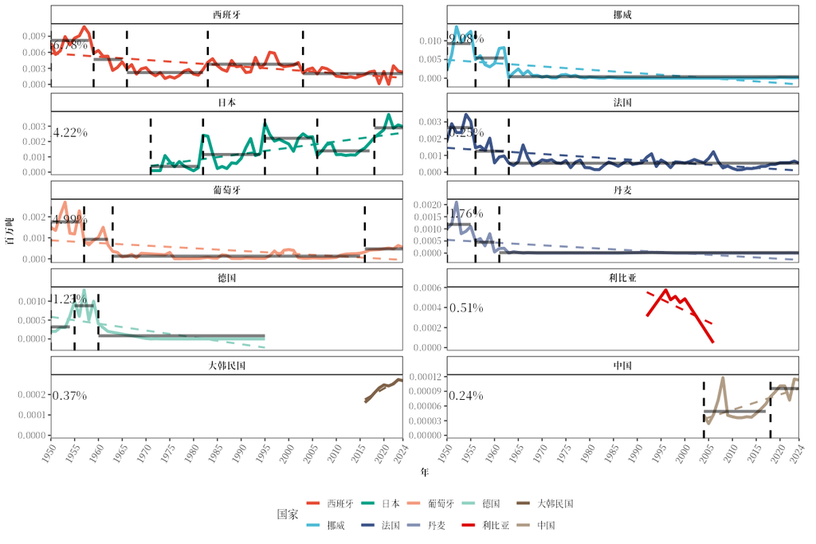

## 2️⃣ `country_species()`：某个国家在渔区内捕什么

```r
norway <- country_species(FAO27$area_data, country_name = "Norway")
```

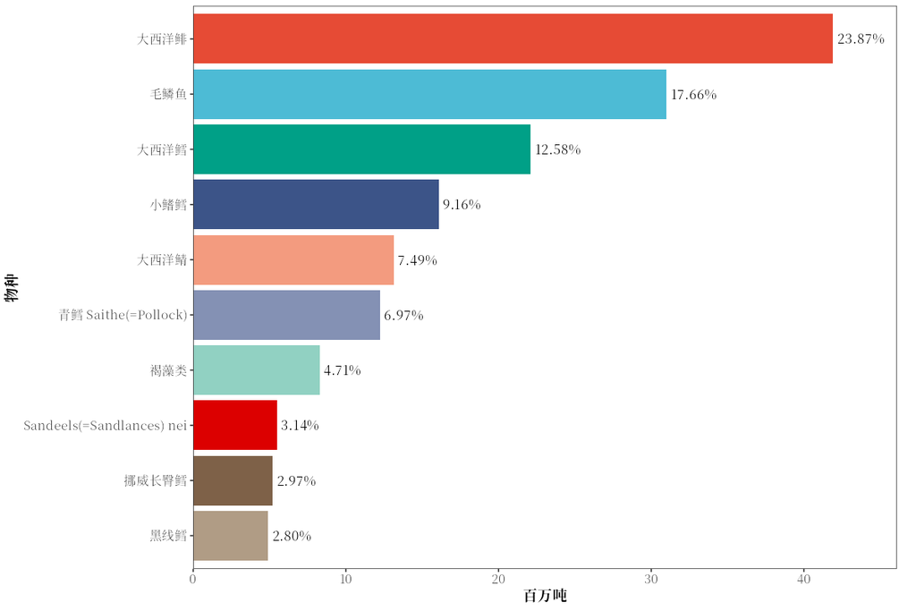

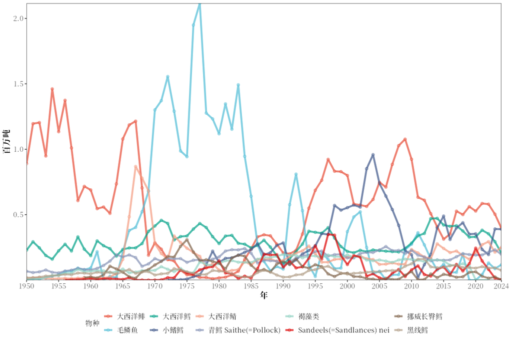

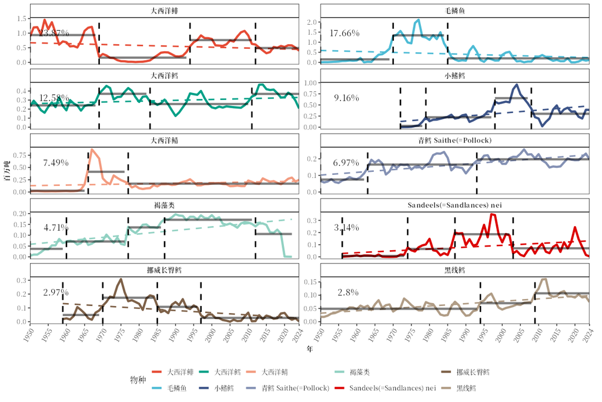

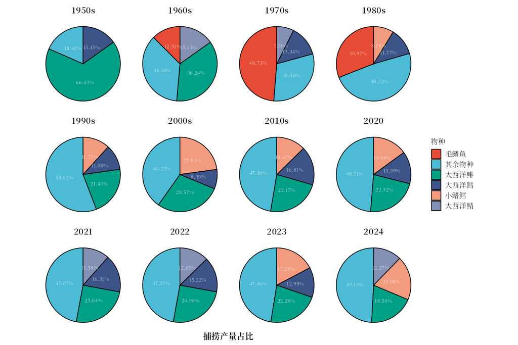

文件名中的`<country>`是把国家名中的空格和标点替换为`_`后的名称：

| 文件 | 图表 |
| --- | --- |
| `country/<country>_species_ranked_total.png` | 该国所选物种（默认为前十名）的总产量及占比 |
| `country/<country>_species_ranked.png` | 这些物种的产量随时间的变化 |
| `country/<country>_species_ranked_wrap.png` | 每个物种一个分面，标出占比、趋势和突变点 |
| `country/<country>_species_pie_selected.png` | 各物种在各年代以及当前年代逐年的占比 |
| `tables/<country>_country_ranked_table.csv` | 每个物种各年代的平均产量、最近五年的产量和最后一年的占比 |

函数返回所选物种逐年的产量。

`time_analysis_text_displacement`用来移动分面图中占比标签的位置（以首次出现产量后的年数计），当标签与曲线重叠时很有用：

```r
country_species(FAO27$area_data, country_name = "Spain", h_value = 5,
                time_analysis_text_displacement = 6, lang = "both")
```

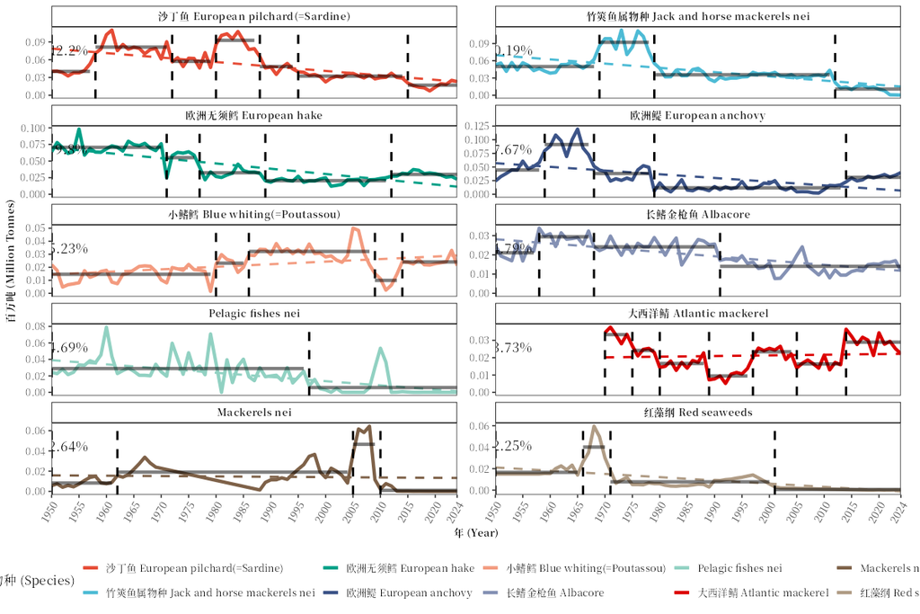

| 参数 | 含义 | 默认值 |
| --- | --- | --- |
| `area_data` | 渔区产量数据：`fishing_area_data()$area_data`或`load_fao_data()`的任意子集 |  |
| `country_name` | FAO国家名，与数据中一致 |  |
| `rank_range` | 显示的物种名次（按该国历年总产量排序）：`1:10`为前十名，`c(5, 6)`为第五和第六名 | `1:10` |
| `plot` | 保存图表 | `TRUE` |
| `table` | 在`tables/`中保存表格 | `TRUE` |
| `timeseries_analysis` | `TRUE`：分面图显示线性趋势和突变点；`FALSE`：分面图显示平滑（loess）曲线 | `TRUE` |
| `time_analysis_text_displacement` | 分面图中占比标签的位置：首次出现产量后的年数 | `10` |
| `h_value` | 相邻突变点之间时段的最短长度：占序列的比例或年数 | `0.15` |
| `ZH` | 指定中文的旧方式：`TRUE`等同于`lang = "zh"` | `FALSE` |
| `lang` | 图表文字和名称的语言：`"en"`、`"zh"`或`"both"` | `NULL`：`ZH = TRUE`时为`"zh"`，否则使用`fao_settings()`中的语言 |
| `pptx` | 同时保存可编辑的PowerPoint文件 | `FALSE`，或`fao_settings()`中的`pptx` |
| `plot_show` | 保存图表的同时把图画在绘图窗口中（例如RStudio的Plots窗格） | `FALSE`，或`fao_settings()`中的`plot_show` |

## 3️⃣ `country_analysis()`：某个国家在全部FAO渔区的捕捞

`country_analysis()`使用一个国家在**全部**FAO渔区的产量，因此只需提供国家名：

```r
norway_global <- country_analysis(country_name = "Norway")
```

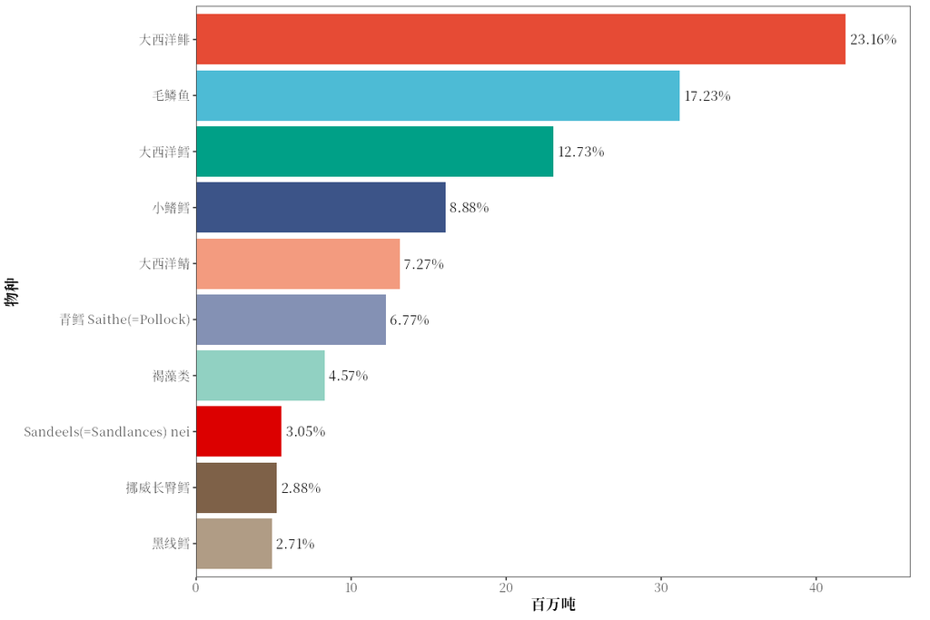

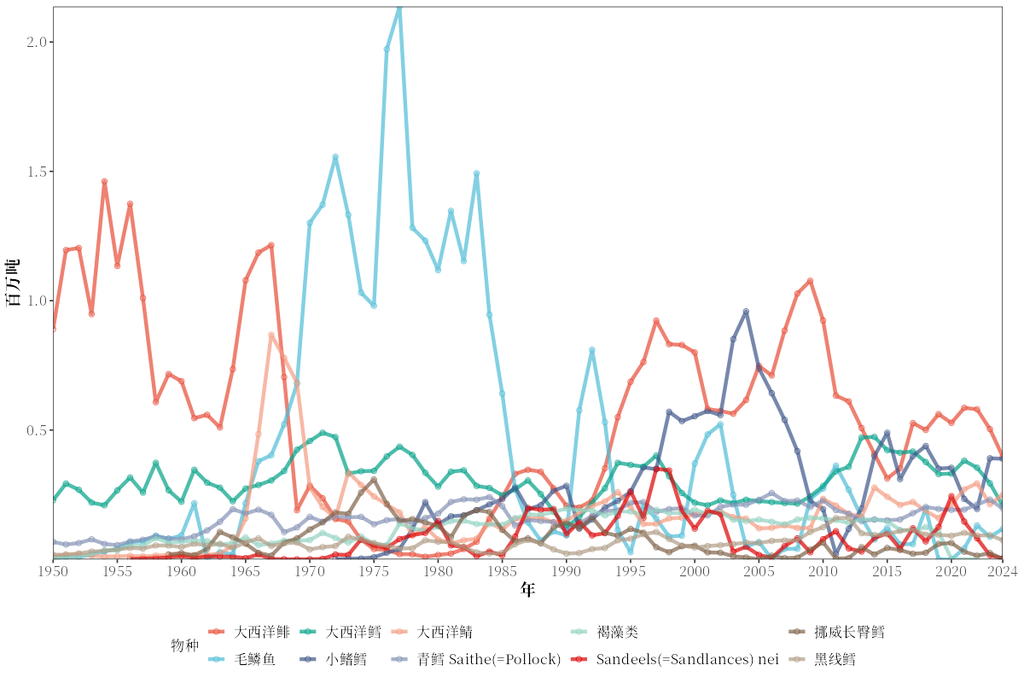

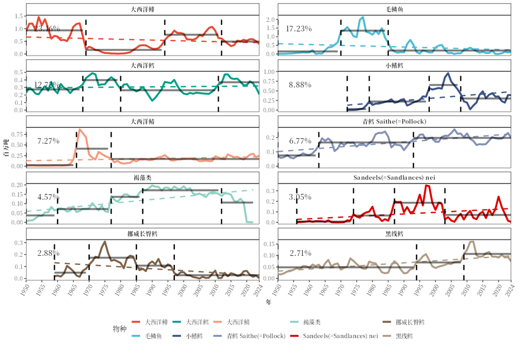

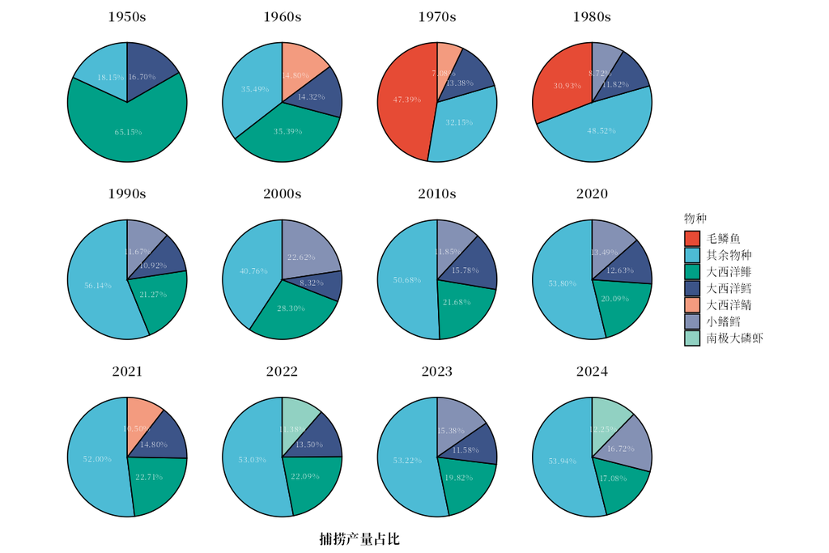

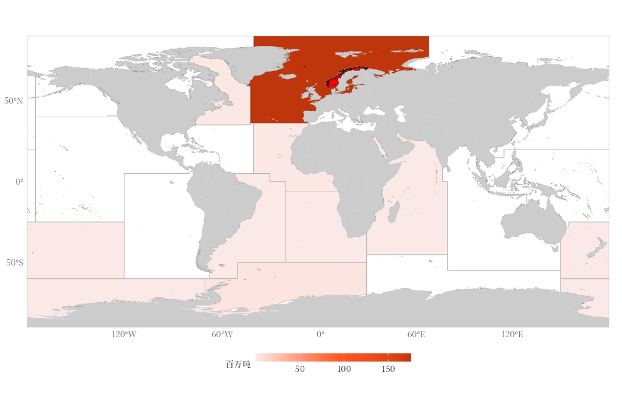

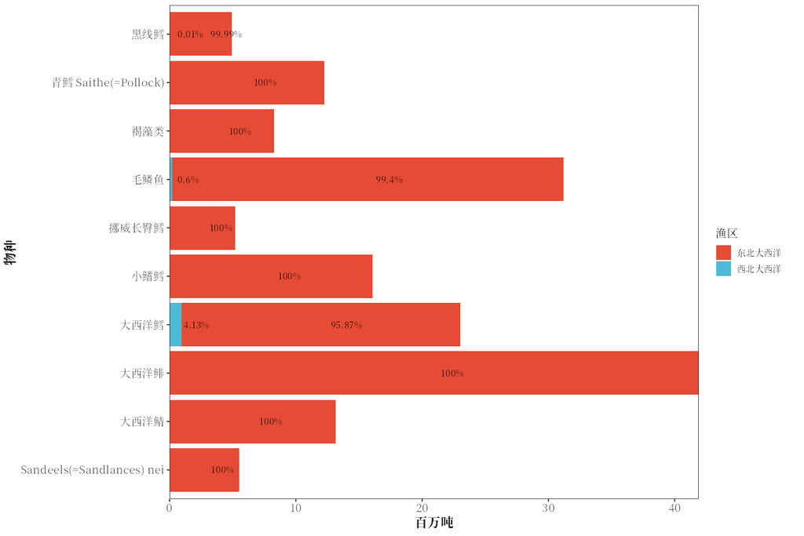

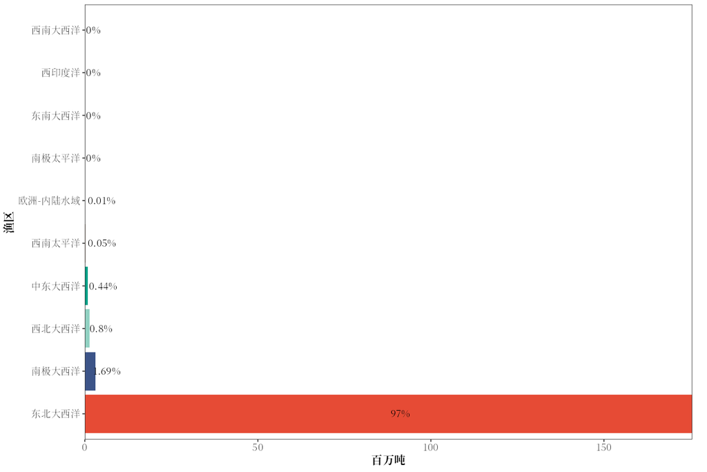

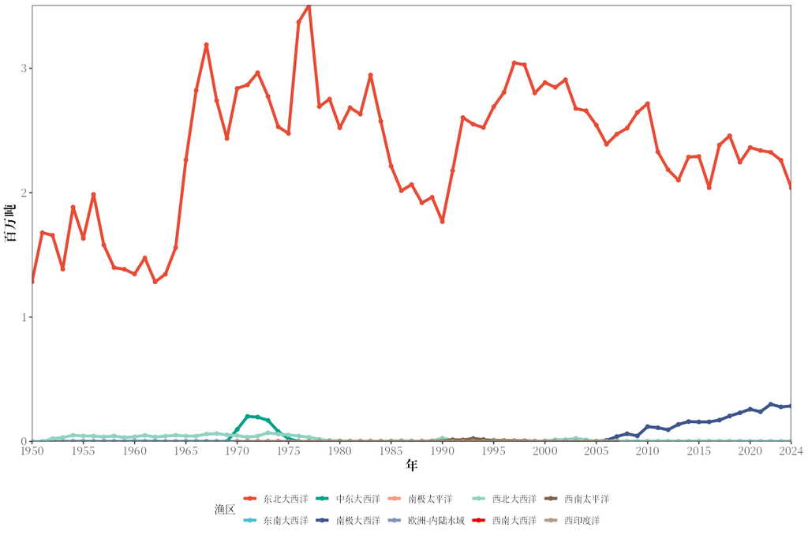

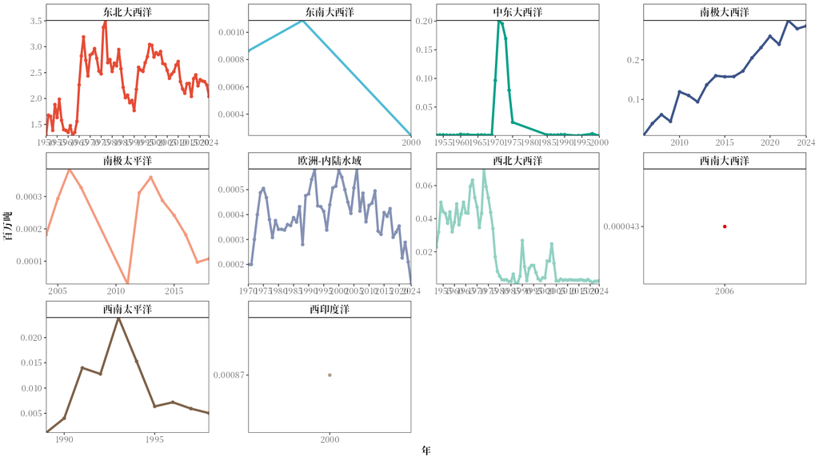

除了物种相关的图表（与`country_species()`相同，文件名为`<country>analysis_...`），它还会保存：

| 文件 | 图表 |
| --- | --- |
| `country/<country>fishing_area_map.png` | 该国在各FAO渔区的总产量，绘制在FAO渔区地图上；该国本身以红色标出 |
| `country/<country>analysis_species_by_area.png` | 主要物种的产量，按渔区拆分，并标出各渔区占该物种产量的比例 |
| `country/<country>analysis_area_total_production.png` | 各渔区的总产量及占比 |
| `country/<country>yearly_area_production.png` | 各渔区产量随时间的变化 |
| `country/<country>yearly_area_production_wrap.png` | 每个渔区一个分面 |
| `tables/<country>analysis_country_ranked_table.csv` | 每个物种各年代的平均产量、最近五年的产量和最后一年的占比 |

函数返回绘图所用的数据：

```r
names(norway_global)
```

```
#> [1] "country_species_ranked"            "country_species_ranked_coefs_data"
#> [3] "table"                             "country_species_area_total"
#> [5] "country_yearly_area_production"
```

```r
show_table(norway_global$country_species_area_total, n = 8, digits = 1)
```

| ASFIS.species..Name. | FAO.major.fishing.area..Name. | area_species_production | total_species_production | percentage_of_total |
| --- | --- | --- | --- | --- |
| 大西洋鲱 | 东北大西洋 | 41,904,457.7 | 41,904,458 | 100.0 |
| 毛鳞鱼 | 东北大西洋 | 30,995,470.2 | 31,182,216 | 99.4 |
| 毛鳞鱼 | 西北大西洋 | 186,746.0 | 31,182,216 | 0.6 |
| 大西洋鳕 | 东北大西洋 | 22,086,713.3 | 23,039,382 | 95.9 |
| 大西洋鳕 | 西北大西洋 | 952,668.4 | 23,039,382 | 4.1 |
| 小鳍鳕 | 东北大西洋 | 16,072,409.4 | 16,072,409 | 100.0 |
| 大西洋鲭 | 东北大西洋 | 13,148,795.6 | 13,148,796 | 100.0 |
| 青鳕 Saithe(=Pollock) | 东北大西洋 | 12,242,719.4 | 12,242,806 | 100.0 |

| 元素 | 内容 |
| --- | --- |
| `country_species_ranked` | 所选物种逐年的产量 |
| `country_species_ranked_coefs_data` | 这些物种的突变点 |
| `table` | 保存在`tables/`中的表格 |
| `country_species_area_total` | 所选物种在各渔区的产量，以及各渔区占该物种产量的比例 |
| `country_yearly_area_production` | 各渔区逐年的产量，以及占该国当年总产量的比例 |

| 参数 | 含义 | 默认值 |
| --- | --- | --- |
| `country_name` | FAO国家名，与数据中一致 |  |
| `rank_range` | 显示的物种名次（按该国历年总产量排序）：`1:10`为前十名，`c(5, 6)`为第五和第六名 | `1:10` |
| `plot` | 保存图表 | `TRUE` |
| `table` | 在`tables/`中保存表格 | `TRUE` |
| `timeseries_analysis` | `TRUE`：物种分面图显示线性趋势和突变点；`FALSE`：显示平滑曲线 | `TRUE` |
| `time_analysis_text_displacement` | 分面图中占比标签的位置：首次出现产量后的年数 | `10` |
| `h_value` | 相邻突变点之间时段的最短长度：占序列的比例或年数 | `0.15` |
| `ZH` | 指定中文的旧方式：`TRUE`等同于`lang = "zh"` | `FALSE` |
| `fill_scale` | 渔区地图的色板，可用`fao_settings()`中`map_palette`的任一取值 | `NULL`：`fao_settings()`中的`map_palette` |
| `lang` | 图表文字和名称的语言：`"en"`、`"zh"`或`"both"` | `NULL`：`ZH = TRUE`时为`"zh"`，否则使用`fao_settings()`中的语言 |
| `data_version` | FAO数据版本：`"latest"`、`"bundled"`或具体版本号（如`"2026.1.0"`，见💾 FAO数据） | `"latest"` |
| `pptx` | 同时保存可编辑的PowerPoint文件 | `FALSE`，或`fao_settings()`中的`pptx` |
| `plot_show` | 保存图表的同时把图画在绘图窗口中（例如RStudio的Plots窗格） | `FALSE`，或`fao_settings()`中的`plot_show` |

突变点的识别方法见🌊 渔区分析（用`strucchange::breakpoints()`拟合各时段均值不变的模型）。

国家名采用FAO的名称，例如`"Korea, Republic of"`、`"Russian Federation"`、`"Taiwan Province of China"`。可以这样查找：`grep("Korea", unique(load_fao_data()$Country..Name.), value = TRUE)`。

## 📖 参考文献

Bai, J. and Perron, P. (2003). Computation and analysis of multiple structural change models. *Journal of Applied Econometrics* 18(1): 1–22. [doi:10.1002/jae.659](https://doi.org/10.1002/jae.659)

FAO (2026). FishStat: Global capture production 1950–2024 (release 2026.1.0). In: FishStatJ. https://www.fao.org/fishery/statistics/software/fishstatj/en. Licence: CC-BY-4.0. Release file: https://www.fao.org/fishery/static/Data/Capture_2026.1.0.zip

FAO. *ASFIS List of Species for Fishery Statistics Purposes*. Rome: FAO. https://www.fao.org/fishery/collection/asfis/en

FAO (2024). FAO Major Fishing Areas for Statistical Purposes. In: FAO Fisheries and Aquaculture Division [online]. Licence: CC-BY 4.0. https://www.fao.org/fishery/geonetwork?uuid=ac02a460-da52-11dc-9d70-0017f293bd28 (the area boundaries of the fishing area map, bundled as `inst/extdata/FAO_AREAS_CWP.shp`)

Natural Earth. Admin 0 – Details, map units, 1:50m (the country outlines of the maps). https://www.naturalearthdata.com/downloads/50m-cultural-vectors/50m-admin-0-details/

Pebesma, E. (2018). Simple features for R: standardized support for spatial vector data. *The R Journal* 10(1): 439–446. [doi:10.32614/RJ-2018-009](https://doi.org/10.32614/RJ-2018-009)

Zeileis, A., Kleiber, C., Krämer, W. and Hornik, K. (2003). Testing and dating of structural changes in practice. *Computational Statistics & Data Analysis* 44(1–2): 109–123. doi:10.1016/S0167-9473(03)00030-6

Zeileis, A., Leisch, F., Hornik, K. and Kleiber, C. (2002). strucchange: an R package for testing for structural change in linear regression models. *Journal of Statistical Software* 7(2): 1–38. [doi:10.18637/jss.v007.i02](https://doi.org/10.18637/jss.v007.i02)